# The Fast and the Mapped: A Demo of Digital Mapping

## Introduction

- You don't need any artistic talent to make digital maps
- You also don't need to know how to code

## Introduction

- You don't need any artistic talent to make digital maps
- You also don't need to know how to code

[figure not shown]

- All you need is some free software and some practice

## Examples

[figure not shown]

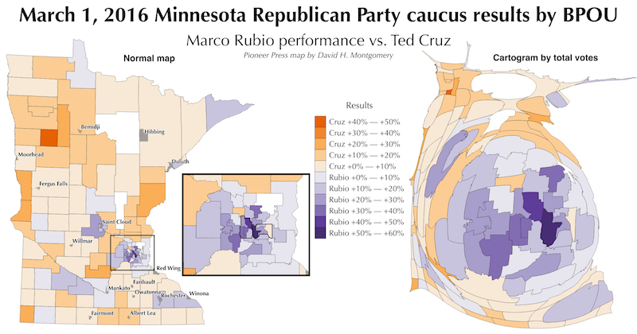

## Live demo

## Free software: QGIS

- http://qgis.org
- Works on Mac, Windows and Linux
- If you work for an employer with money, you might get to use fancy commercial software like ArcGIS

## Free data

To make a map, you need digital data. Fortunately, there's tons of it available for free.

The format you'll mostly want is called the "Shapefile." (It's actually a group of files with the same name but different extensions.)

Some sources:

- naturalearthdata.com/
- census.gov/geo/maps-data/
- gisdata.mn.gov
- opendata.minneapolismn.gov
- hennepin.us/gisopendata

## Next steps

I've demonstrated some techniques for making simple but attractive maps in QGIS. But it can do a lot more than I've shown you today.

For example, QGIS can:

- Match up basic geography with data such as election results, test scores or pollution levels
- Find every house located within the half-mile blast zone of an oil train route
- Calculate the percentage of every Minnesota county's land area made up of lakes
- Calculate which latitude/longitude points fall inside which of a given set of boundaries

## Learn more

- Google is your friend
- meetup.com/MaptimeMSP/
- Ask me questions on Twitter @dhmontgomery
- This slide deck: dmont.co/nerdmaps
- My step-by-step guide to making this map: dmont.co/nerdmapguide